# Sheltered vs. Unsheltered Codebook

2024-08-16

# Overview

This codebook summarizes findings and data about Sleep Status for Sheltered and Unsheltered based on data from the University of Washington (UW) 2023 Seattle area homeless count project. The count was led by Zack W. Almquist (*Lead - PI*), Paul Hebert (*Co-PI*), Nathalie Williams (*Puget Sound Data Oversample PI*), Amy Hagopian (*Co-PI*), June (Junhe) Yang (*Data Scientist Lead DSSG PhD*).

The data were collected using two different surveys, referred to as **UWRDS** and **UWRDS-PSD** in the codebook. Data from both surveys were harmonized for this codebook. We note where question phrasing differed across surveys and when a variable was collected in only one survey.

This codebook and corresponding links were compiled by Data Science for Social Good (DSSG) summer fellows, in alphabetical order:  
- Felix Junior Appiah Kubi,  
- Brooke Kaye,  
- Jess Robinson, and  
- Rebecca Schachtman,  
with the support of Data Scientist, June (Junhe) Yang, and Project Lead, Zack Almquist.

We employ RDS methods for the population level statistics (details, [here](https://uwescience.github.io/DSSG2024_understanding_homelessness/method1/)). For information on funding and a full list of contributors, see [Acknowledgements](https://uwescience.github.io/DSSG2024_understanding_homelessness/acknowledgements/).

# Summary

Sleep Status

Sample N

Sample Proportion

RDS II Estimate

RDS II 95% CI

Sheltered

111

13%

14%

[9%, 20%]

Unsheltered

748

87%

86%

[80%, 91%]

Total

859

100%

100%

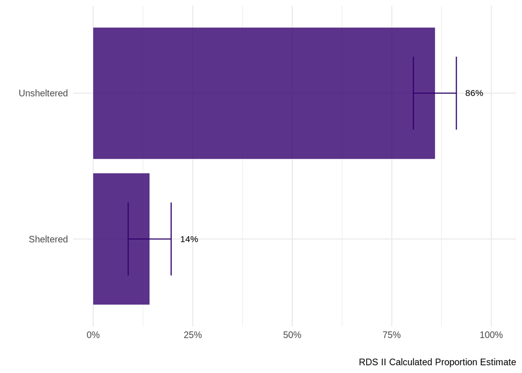

The proportion of the population experiencing homeless who are Sheltered is 14%. The proportion of the population experiencing homeless who are Unsheltered is 86%.

# Demographics

## *Gender*

*Imputed based on ‘B4. How would you describe your gender?’ [UWRDS-PSD] and ‘25. Which of the following best describes your gender?’ [UWRDS]*

Sheltered

Gender

Sample N

Sample Proportion

RDS II Estimate

RDS II 95% CI

A gender other than singularly female or male (e.g., nonbinary, genderfluid, agender, culturally specific gender)

0

NA

NA

NA

Do not know

0

NA

NA

NA

Female

22

20.75%

20.01%

[3.29%, 36.73%]

Male

84

79.25%

79.99%

[63.27%, 96.71%]

Questioning

0

NA

NA

NA

Transgender

0

NA

NA

NA

Total

106

Unsheltered

Gender

Sample N

Sample Proportion

RDS II Estimate

RDS II 95% CI

A gender other than singularly female or male (e.g., nonbinary, genderfluid, agender, culturally specific gender)

7

1.00%

1.15%

[0.32%, 1.99%]

Do not know

1

0.14%

0.19%

[-0.11%, 0.49%]

Female

185

26.32%

25.33%

[18.43%, 32.24%]

Male

504

71.69%

72.29%

[65.39%, 79.19%]

Questioning

3

0.43%

0.52%

[0.35%, 0.70%]

Transgender

3

0.43%

0.51%

[-0.15%, 1.17%]

Total

703

*The difference between individual sheltered and unsheltered is not significant, $\chi^2 = 4.75$, (p = 0.853). These results were calculated based on the mean of 1000 bootstrapped tests. This value was calculated with replacement.*

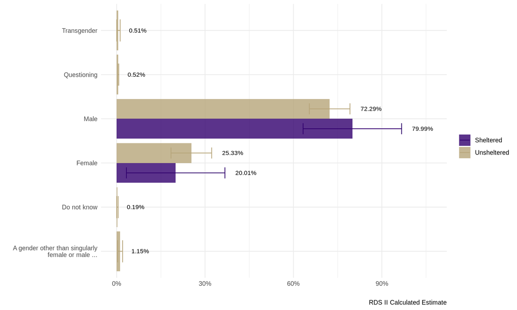

## *Race*

*Imputed based on ‘B18. Which one or more of the following would you say best describes your race, heritage, or ancestry?’ [UWRDS-PSD] and ‘23. Which racial groups do you identify with?’ [UWRDS]*

### *Race (Overall)*

Sheltered

Race

Sample N

Sample Proportion

RDS II Estimate

RDS II 95% CI

American Indian, Alaskan Native or Indigenous

8

7.92%

14.22%

[0.00%, 28.44%]

Another race

1

0.99%

0.80%

[0.33%, 1.28%]

Asian or Asian American

9

8.91%

9.64%

[-1.41%, 20.69%]

Black, African American, or African

20

19.80%

22.71%

[6.29%, 39.13%]

Do not know

1

0.99%

2.41%

[-10.96%, 15.79%]

Multiracial

14

13.86%

13.28%

[2.68%, 23.88%]

Native Hawaiian or Pacific Islander

3

2.97%

2.87%

[-1.22%, 6.97%]

White

45

44.55%

34.06%

[14.40%, 53.72%]

Total

101

Unsheltered

Race

Sample N

Sample Proportion

RDS II Estimate

RDS II 95% CI

American Indian, Alaskan Native or Indigenous

50

7.45%

7.21%

[3.50%, 10.91%]

Another race

11

1.64%

2.62%

[-0.24%, 5.48%]

Asian or Asian American

10

1.49%

2.32%

[-1.12%, 5.76%]

Black, African American, or African

101

15.05%

16.60%

[10.99%, 22.22%]

Do not know

12

1.79%

2.09%

[-0.95%, 5.12%]

Multiracial

93

13.86%

14.99%

[9.48%, 20.50%]

Native Hawaiian or Pacific Islander

14

2.09%

2.09%

[0.16%, 4.03%]

White

380

56.63%

52.08%

[44.58%, 59.57%]

Total

671

*The difference between individual sheltered and unsheltered is not significant, $\chi^2 = 30.1$, (p = 0.263). These results were calculated based on the mean of 1000 bootstrapped tests. This value was calculated with replacement.*

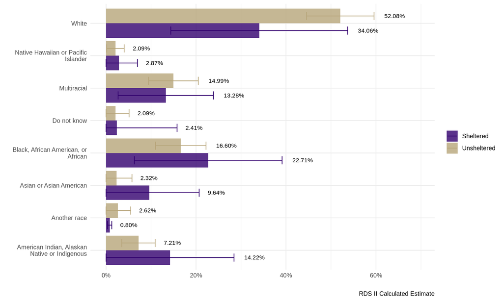

### *Race - Multiracial (Black)*

*Imputed racial category that classifies multiracial individuals as one race with preference to Black based on ‘23. Which racial groups do you identify with?’*

Sheltered

Race

Sample N

Sample Proportion

RDS II Estimate

RDS II 95% CI

American Indian, Alaskan Native or Indigenous

14

13.86%

19.41%

[5.31%, 33.51%]

Another race

1

0.99%

0.80%

[0.33%, 1.28%]

Asian or Asian American

10

9.90%

10.85%

[-0.22%, 21.92%]

Black, African American, or African

26

25.74%

29.44%

[11.50%, 47.38%]

Do not know

1

0.99%

2.41%

[-10.96%, 15.79%]

Native Hawaiian or Pacific Islander

4

3.96%

3.03%

[-1.05%, 7.12%]

White

45

44.55%

34.06%

[14.40%, 53.72%]

Total

101

Unsheltered

Race

Sample N

Sample Proportion

RDS II Estimate

RDS II 95% CI

American Indian, Alaskan Native or Indigenous

94

14.01%

14.51%

[9.05%, 19.97%]

Another race

11

1.64%

2.62%

[-0.24%, 5.48%]

Asian or Asian American

13

1.94%

2.80%

[-0.72%, 6.33%]

Black, African American, or African

137

20.42%

21.57%

[15.76%, 27.39%]

Do not know

12

1.79%

2.09%

[-0.95%, 5.12%]

Native Hawaiian or Pacific Islander

21

3.13%

3.91%

[0.17%, 7.65%]

White

383

57.08%

52.49%

[44.99%, 59.99%]

Total

671

*The difference between individual sheltered and unsheltered is not significant, $\chi^2 = 26.97$, (p = 0.208). These results were calculated based on the mean of 1000 bootstrapped tests. This value was calculated with replacement.*

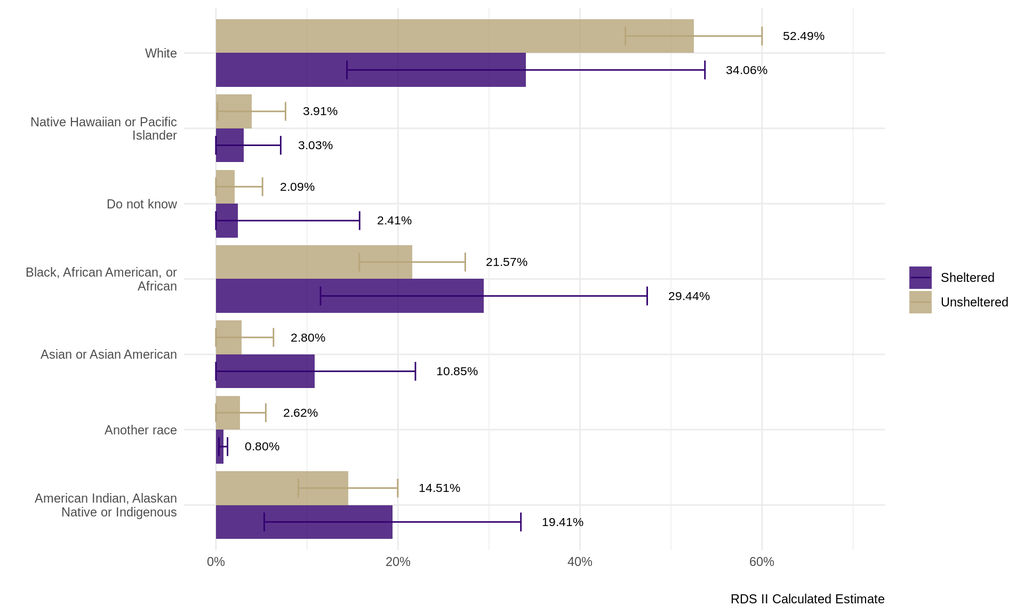

### *Race - Multiracial (Indigenous)*

*Imputed racial category that classifies multiracial individuals as one race with preference to Indigenous based on ‘23. Which racial groups do you identify with?’*

Sheltered

Race (Indigeneous)

Sample N

Sample Proportion

RDS II Estimate

RDS II 95% CI

American Indian, Alaskan Native or Indigenous

20

19.80%

26.14%

[9.53%, 42.74%]

Another race

1

0.99%

0.80%

[0.33%, 1.28%]

Asian or Asian American

10

9.90%

10.85%

[-0.22%, 21.92%]

Black, African American, or African

20

19.80%

22.71%

[6.29%, 39.13%]

Do not know

1

0.99%

2.41%

[-10.96%, 15.79%]

Native Hawaiian or Pacific Islander

4

3.96%

3.03%

[-1.05%, 7.12%]

White

45

44.55%

34.06%

[14.40%, 53.72%]

Total

101

Unsheltered

Race (Indigeneous)

Sample N

Sample Proportion

RDS II Estimate

RDS II 95% CI

American Indian, Alaskan Native or Indigenous

122

18.18%

18.34%

[12.73%, 23.94%]

Another race

11

1.64%

2.62%

[-0.24%, 5.48%]

Asian or Asian American

13

1.94%

2.80%

[-0.72%, 6.33%]

Black, African American, or African

109

16.24%

17.75%

[12.08%, 23.42%]

Do not know

12

1.79%

2.09%

[-0.95%, 5.12%]

Native Hawaiian or Pacific Islander

21

3.13%

3.91%

[0.17%, 7.65%]

White

383

57.08%

52.49%

[44.99%, 59.99%]

Total

671

*The difference between individual sheltered and unsheltered is not significant, $\chi^2 = 27.12$, (p = 0.201). These results were calculated based on the mean of 1000 bootstrapped tests. This value was calculated with replacement.*

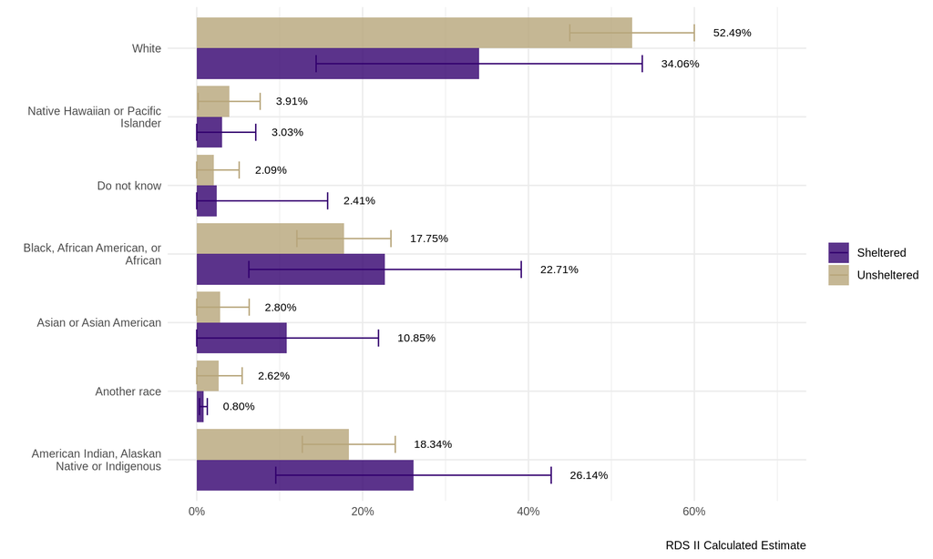

### *Race - Multiracial (Native Hawaiian or Pacific Islander)*

*Imputed racial category that classifies multiracial individuals as one race with preference to Native Hawaiian or Pacific Islander based on ‘23. Which racial groups do you identify with?’*

Sheltered

Race (PI)

Sample N

Sample Proportion

RDS II Estimate

RDS II 95% CI

American Indian, Alaskan Native or Indigenous

14

13.86%

19.41%

[5.310%, 33.51%]

Another race

1

0.99%

0.80%

[0.330%, 1.28%]

Asian or Asian American

10

9.90%

10.85%

[-0.220%, 21.92%]

Black, African American, or African

23

22.77%

25.82%

[7.730%, 43.91%]

Do not know

1

0.99%

2.41%

[-10.960%, 15.79%]

Native Hawaiian or Pacific Islander

7

6.93%

6.65%

[1.970%, 11.32%]

White

45

44.55%

34.06%

[14.400%, 53.72%]

Total

101

Unsheltered

Race (PI)

Sample N

Sample Proportion

RDS II Estimate

RDS II 95% CI

American Indian, Alaskan Native or Indigenous

87

12.97%

13.01%

[7.740%, 18.29%]

Another race

11

1.64%

2.62%

[-0.240%, 5.48%]

Asian or Asian American

13

1.94%

2.80%

[-0.720%, 6.33%]

Black, African American, or African

123

18.33%

19.29%

[13.570%, 25.01%]

Do not know

12

1.79%

2.09%

[-0.950%, 5.12%]

Native Hawaiian or Pacific Islander

42

6.26%

7.69%

[3.500%, 11.89%]

White

383

57.08%

52.49%

[44.990%, 59.99%]

Total

671

*The difference between individual sheltered and unsheltered is not significant, $\chi^2 = 27.6$, (p = 0.19). These results were calculated based on the mean of 1000 bootstrapped tests. This value was calculated with replacement.*

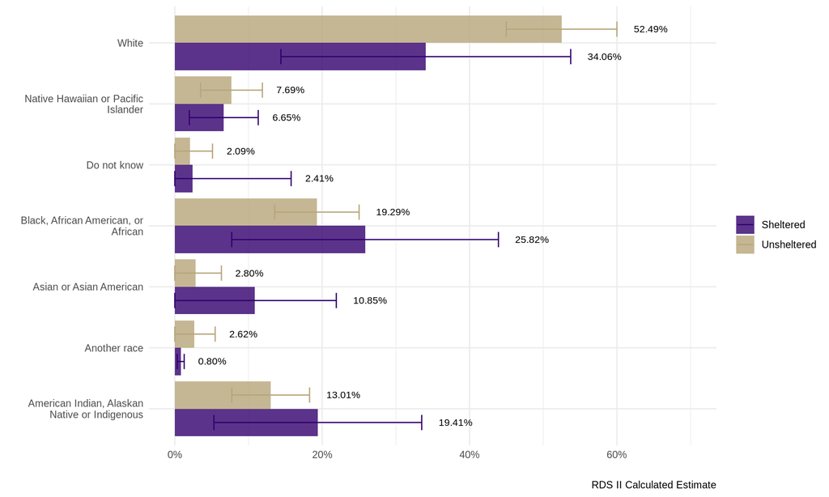

## *Ethnicity*

*Imputed based on ‘B16. Do you consider yourself Hispanic or Latinx’ [UWRDS-PSD] and ‘24. What is your ethnicity?’ [UWRDS]*

Sheltered

Ethnicity

Sample N

Sample Proportion

RDS II Estimate

RDS II 95% CI

Do not know

4

3.96%

5.10%

[-6.5%, 16.7%]

Hispanic/Latin(a)(o)(x)

15

14.85%

15.77%

[-1.1%, 32.6%]

Non-Hispanic/Non-Latin(a)(o)(x)

82

81.19%

79.13%

[60.2%, 98.0%]

Total

101

Unsheltered

Ethnicity

Sample N

Sample Proportion

RDS II Estimate

RDS II 95% CI

Do not know

15

2.18%

1.75%

[1.1%, 2.4%]

Hispanic/Latin(a)(o)(x)

99

14.41%

15.64%

[10.2%, 21.1%]

Non-Hispanic/Non-Latin(a)(o)(x)

573

83.41%

82.61%

[77.1%, 88.1%]

Total

687

*The difference between individual sheltered and unsheltered is not significant, $\chi^2 = 4.98$, (p = 0.646). These results were calculated based on the mean of 1000 bootstrapped tests. This value was calculated with replacement.*

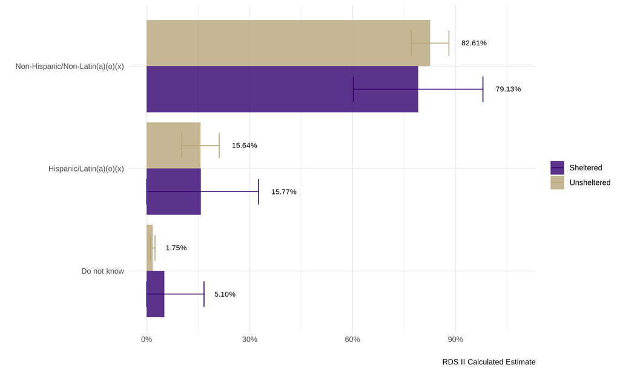

## *Age*

*Date of Birth*

### *Age (Categorical)*

*Imputed based on ‘A2. How old are you?’ [UWRDS-PSD] and ‘4. Date of Birth’ [UWRDS]*

Sheltered

Age Category

Sample N

Sample Proportion

RDS II Estimate

RDS II 95% CI

18-24

3

2.83%

4.44%

[-6.20%, 15.07%]

25-34

14

13.21%

15.37%

[2.46%, 28.28%]

35-44

34

32.08%

29.20%

[13.58%, 44.82%]

45-54

19

17.92%

20.63%

[3.58%, 37.68%]

55-64

26

24.53%

21.27%

[7.68%, 34.86%]

65+

10

9.43%

9.10%

[-2.15%, 20.35%]

Total

106

Unsheltered

Age Category

Sample N

Sample Proportion

RDS II Estimate

RDS II 95% CI

18-24

18

2.55%

2.96%

[0.13%, 5.79%]

25-34

153

21.67%

23.18%

[16.79%, 29.58%]

35-44

215

30.45%

29.77%

[23.23%, 36.30%]

45-54

176

24.93%

23.26%

[17.26%, 29.26%]

55-64

113

16.01%

15.72%

[11.50%, 19.93%]

65+

31

4.39%

5.12%

[1.48%, 8.76%]

Total

706

*The difference between individual sheltered and unsheltered is not significant, $\chi^2 = 8.43$, (p = 0.331). These results were calculated based on the mean of 1000 bootstrapped tests. This value was calculated with replacement.*

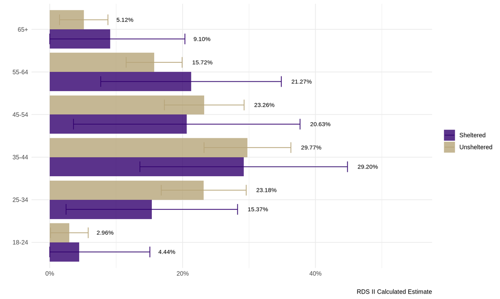

### *Age (Continuous)*

*Age - Imputed from ‘4. Date of Birth’*

| Sleep Status | Sample N | Sample Median | Sample Mean | Sample SE | RDS II Estimate | RDS II 95% CI |
| --- | --- | --- | --- | --- | --- | --- |
| Unsheltered | 706 | 42 | 43.88 | 0.46 | 43.80 | [41.83, 45.77] |
| Sheltered | 106 | 46 | 46.96 | 1.28 | 45.97 | [40.77, 51.18] |

*The difference between individual sheltered and unsheltered is not significant, t(418.72) = 0.77, (p= 0.444).*

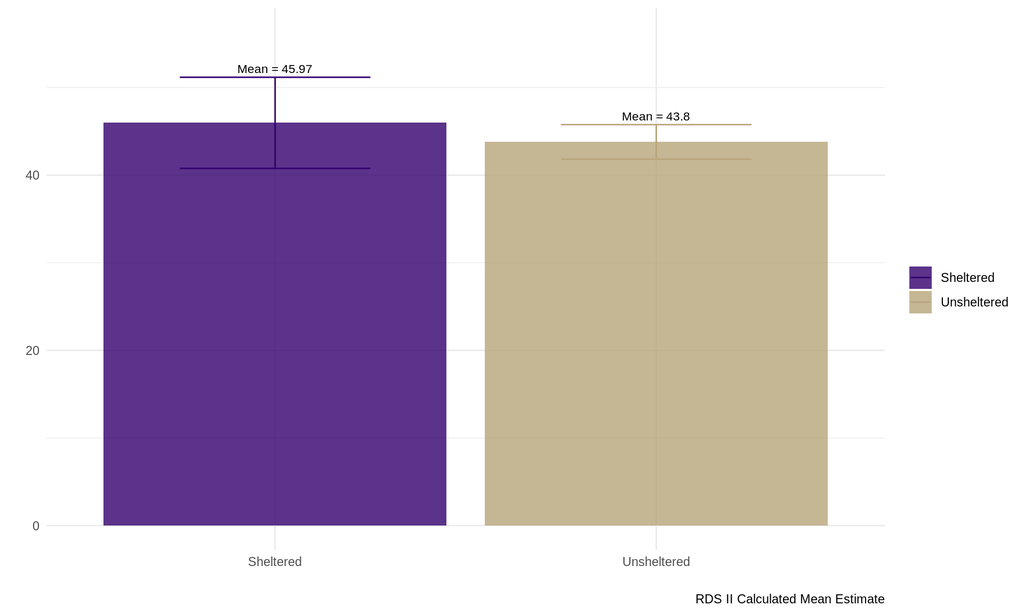

## *Birthplace*

### *Birth State*

*‘8. Birthplace: - State - In what city and state were you born? - Imputed’ This variable is not included for UWRDS-PSD survey observations.*

Sheltered

Birth State

Sample N

Sample Proportion

RDS II Estimate

RDS II 95% CI

Alabama

1

1.32%

3.360%

[-4.74%, 11.47%]

Alaska

1

1.32%

0.220%

[0.04%, 0.41%]

Arizona

0

NA

NA

NA

Arkansas

0

NA

NA

NA

California

10

13.16%

12.260%

[-1.79%, 26.31%]

Colorado

1

1.32%

1.120%

[-0.04%, 2.28%]

Connecticut

0

NA

NA

NA

Florida

1

1.32%

3.360%

[-11.31%, 18.04%]

Georgia

1

1.32%

3.360%

[-3.72%, 10.45%]

Hawaii

0

NA

NA

NA

Idaho

1

1.32%

0.480%

[0.13%, 0.83%]

Illinois

1

1.32%

0.480%

[-0.06%, 1.02%]

Indiana

0

NA

NA

NA

Iowa

2

2.63%

5.050%

[-10.48%, 20.57%]

Kansas

1

1.32%

1.680%

[0.51%, 2.85%]

Kentucky

1

1.32%

1.120%

[-0.69%, 2.93%]

Louisiana

2

2.63%

5.050%

[-6.19%, 16.29%]

Maine

0

NA

NA

NA

Massachusetts

0

NA

NA

NA

Michigan

4

5.26%

3.030%

[1.41%, 4.65%]

Minnesota

1

1.32%

1.680%

[0.12%, 3.24%]

Missouri

2

2.63%

0.790%

[0.15%, 1.42%]

Montana

1

1.32%

1.120%

[-0.06%, 2.30%]

Nebraska

0

NA

NA

NA

Nevada

0

NA

NA

NA

New Jersey

1

1.32%

0.220%

[0.01%, 0.44%]

New Mexico

0

NA

NA

NA

New York

1

1.32%

0.840%

[0.20%, 1.48%]

North Carolina

1

1.32%

1.680%

[-1.05%, 4.42%]

North Dakota

1

1.32%

0.480%

[0.10%, 0.86%]

Ohio

2

2.63%

2.800%

[-2.53%, 8.13%]

Oklahoma

1

1.32%

0.840%

[0.34%, 1.35%]

Oregon

4

5.26%

4.320%

[2.26%, 6.37%]

Pennsylvania

3

3.95%

2.640%

[-3.18%, 8.45%]

South Carolina

0

NA

NA

NA

South Dakota

1

1.32%

0.220%

[0.04%, 0.41%]

Tennessee

1

1.32%

1.120%

[0.12%, 2.12%]

Texas

1

1.32%

0.480%

[0.11%, 0.86%]

Utah

0

NA

NA

NA

Vermont

0

NA

NA

NA

Virginia

0

NA

NA

NA

Washington

25

32.89%

34.710%

[14.24%, 55.18%]

West Virginia

1

1.32%

0.420%

[0.10%, 0.74%]

Wisconsin

1

1.32%

3.360%

[0.82%, 5.91%]

Wyoming

0

NA

NA

NA

New Hampshire

1

1.32%

1.680%

[-3.53%, 6.89%]

Total

76

Unsheltered

Birth State

Sample N

Sample Proportion

RDS II Estimate

RDS II 95% CI

Alabama

5

0.93%

1.130%

[-1.79%, 4.04%]

Alaska

13

2.42%

2.250%

[1.01%, 3.50%]

Arizona

8

1.49%

2.270%

[-1.41%, 5.94%]

Arkansas

5

0.93%

1.180%

[0.04%, 2.33%]

California

50

9.31%

8.270%

[4.65%, 11.88%]

Colorado

9

1.68%

1.130%

[0.70%, 1.56%]

Connecticut

2

0.37%

0.130%

[0.08%, 0.17%]

Florida

14

2.61%

2.980%

[-0.11%, 6.06%]

Georgia

3

0.56%

0.720%

[-0.06%, 1.50%]

Hawaii

2

0.37%

0.720%

[-2.21%, 3.64%]

Idaho

4

0.74%

1.120%

[-1.35%, 3.58%]

Illinois

15

2.79%

3.130%

[1.23%, 5.03%]

Indiana

3

0.56%

0.630%

[0.27%, 0.98%]

Iowa

2

0.37%

0.720%

[-2.12%, 3.56%]

Kansas

8

1.49%

2.000%

[-1.50%, 5.51%]

Kentucky

4

0.74%

0.340%

[0.17%, 0.52%]

Louisiana

4

0.74%

0.340%

[-0.07%, 0.75%]

Maine

1

0.19%

0.130%

[0.10%, 0.17%]

Massachusetts

3

0.56%

0.780%

[0.36%, 1.20%]

Michigan

5

0.93%

0.630%

[-0.17%, 1.44%]

Minnesota

6

1.12%

1.980%

[-0.61%, 4.57%]

Missouri

4

0.74%

0.530%

[0.01%, 1.04%]

Montana

11

2.05%

1.930%

[-1.23%, 5.10%]

Nebraska

3

0.56%

0.630%

[-2.19%, 3.45%]

Nevada

1

0.19%

0.540%

[0.24%, 0.83%]

New Jersey

7

1.30%

1.690%

[-0.62%, 4.00%]

New Mexico

6

1.12%

1.480%

[-1.84%, 4.79%]

New York

9

1.68%

1.760%

[-0.88%, 4.40%]

North Carolina

1

0.19%

0.180%

[-0.11%, 0.47%]

North Dakota

2

0.37%

0.330%

[0.10%, 0.55%]

Ohio

6

1.12%

1.640%

[-0.98%, 4.25%]

Oklahoma

4

0.74%

1.390%

[-1.45%, 4.23%]

Oregon

12

2.23%

2.570%

[0.61%, 4.54%]

Pennsylvania

4

0.74%

0.570%

[0.27%, 0.86%]

South Carolina

1

0.19%

0.080%

[0.05%, 0.11%]

South Dakota

1

0.19%

0.270%

[-0.77%, 1.31%]

Tennessee

7

1.30%

0.660%

[-0.31%, 1.64%]

Texas

19

3.54%

4.190%

[1.91%, 6.46%]

Utah

4

0.74%

0.750%

[-0.27%, 1.77%]

Vermont

1

0.19%

0.130%

[0.00%, 0.27%]

Virginia

2

0.37%

0.640%

[-2.14%, 3.43%]

Washington

261

48.60%

44.640%

[36.54%, 52.74%]

West Virginia

1

0.19%

0.180%

[-0.14%, 0.50%]

Wisconsin

3

0.56%

0.480%

[0.29%, 0.68%]

Wyoming

1

0.19%

0.180%

[0.13%, 0.23%]

New Hampshire

0

NA

NA

NA

Total

537

*The difference between individual sheltered and unsheltered is not significant, $\chi^2 = 77.79$, (p = 0.981). These results were calculated based on the mean of 1000 bootstrapped tests.*

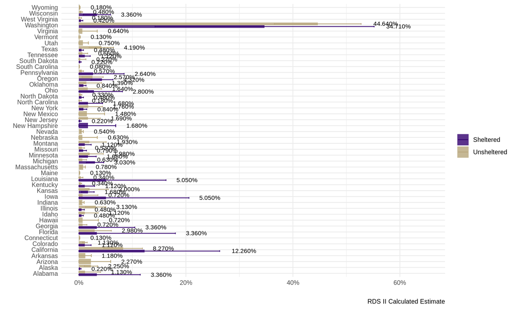

### *Birth Country*

*‘8. Birthplace: - Country - In what city and state were you born? - Imputed’ This variable is not included for UWRDS-PSD survey observations.*

Sheltered

Birth Country

Sample N

Sample Proportion

RDS II Estimate

RDS II 95% CI

Burma

0

NA

NA

NA

Canada

2

2.25%

5.42%

[-6.93%, 17.78%]

Costa Rica

0

NA

NA

NA

Dominican Republic

0

NA

NA

NA

Ethiopia

1

1.12%

2.71%

[1.68%, 3.75%]

France

0

NA

NA

NA

Germany

0

NA

NA

NA

Grenada

0

NA

NA

NA

Guam

0

NA

NA

NA

Haiti

0

NA

NA

NA

Italy

0

NA

NA

NA

Jordan

0

NA

NA

NA

Kazakhstan

0

NA

NA

NA

Kenya

0

NA

NA

NA

Marianas islands

0

NA

NA

NA

Mexico

1

1.12%

1.36%

[0.30%, 2.41%]

Palau

0

NA

NA

NA

Philippines

0

NA

NA

NA

Romania

0

NA

NA

NA

Russia

0

NA

NA

NA

Scotland

0

NA

NA

NA

South korea

0

NA

NA

NA

UK

0

NA

NA

NA

Ukraine

0

NA

NA

NA

United States

77

86.52%

80.93%

[65.56%, 96.30%]

India

2

2.25%

1.36%

[0.56%, 2.15%]

Iran

1

1.12%

1.36%

[0.78%, 1.93%]

Laos

1

1.12%

1.36%

[0.68%, 2.04%]

Lunpranba

1

1.12%

1.36%

[0.58%, 2.13%]

Mumbai india

1

1.12%

2.71%

[-7.91%, 13.33%]

Puerto Rico

1

1.12%

0.90%

[-1.21%, 3.01%]

Somalia

1

1.12%

0.54%

[0.11%, 0.97%]

Total

89

Unsheltered

Birth Country

Sample N

Sample Proportion

RDS II Estimate

RDS II 95% CI

Burma

1

0.18%

0.50%

[-1.50%, 2.49%]

Canada

2

0.35%

0.20%

[-0.05%, 0.46%]

Costa Rica

1

0.18%

0.50%

[0.39%, 0.60%]

Dominican Republic

1

0.18%

0.05%

[0.02%, 0.08%]

Ethiopia

2

0.35%

0.37%

[0.02%, 0.72%]

France

1

0.18%

0.25%

[-0.29%, 0.79%]

Germany

3

0.53%

0.61%

[-1.64%, 2.86%]

Grenada

1

0.18%

0.25%

[-0.47%, 0.97%]

Guam

2

0.35%

0.66%

[-1.25%, 2.57%]

Haiti

1

0.18%

0.12%

[0.08%, 0.17%]

Italy

1

0.18%

0.25%

[-0.23%, 0.72%]

Jordan

1

0.18%

0.25%

[-0.76%, 1.25%]

Kazakhstan

2

0.35%

0.28%

[-0.11%, 0.67%]

Kenya

1

0.18%

0.03%

[0.02%, 0.04%]

Marianas islands

1

0.18%

0.03%

[0.02%, 0.05%]

Mexico

2

0.35%

0.74%

[-0.30%, 1.79%]

Palau

1

0.18%

0.12%

[-0.05%, 0.30%]

Philippines

3

0.53%

0.91%

[-1.41%, 3.23%]

Romania

1

0.18%

0.17%

[0.06%, 0.27%]

Russia

1

0.18%

0.25%

[-0.69%, 1.18%]

Scotland

1

0.18%

0.25%

[-0.55%, 1.05%]

South korea

1

0.18%

0.17%

[0.11%, 0.22%]

UK

1

0.18%

0.17%

[-0.21%, 0.55%]

Ukraine

1

0.18%

0.17%

[-0.10%, 0.43%]

United States

538

94.22%

92.71%

[88.08%, 97.34%]

India

0

NA

NA

NA

Iran

0

NA

NA

NA

Laos

0

NA

NA

NA

Lunpranba

0

NA

NA

NA

Mumbai india

0

NA

NA

NA

Puerto Rico

0

NA

NA

NA

Somalia

0

NA

NA

NA

Total

571

*The difference between individual sheltered and unsheltered is not significant, $\chi^2 = 85.51$, (p = 0.947). These results were calculated based on the mean of 1000 bootstrapped tests.*

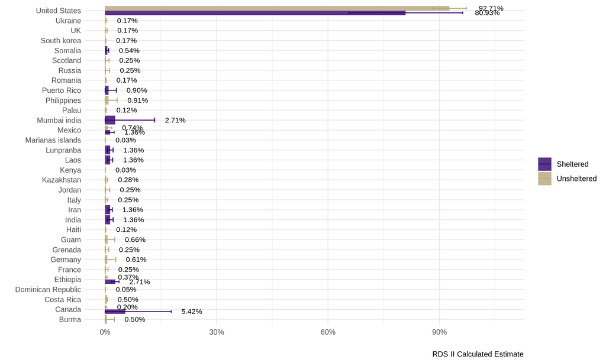

## *Years Lived in King County*

*‘9. How long have you lived in King County? - Imputed’ This variable is not included for UWRDS-PSD survey observations.*

| Sleep Status | Sample N | Sample Median | Sample Mean | Sample SE | RDS II Estimate | RDS II 95% CI |
| --- | --- | --- | --- | --- | --- | --- |
| Unsheltered | 585 | 19 | 21.87 | 0.71 | 20.69 | [17.87, 23.5] |
| Sheltered | 92 | 10 | 17.54 | 1.80 | 16.64 | [10.53, 22.76] |

*The difference between individual sheltered and unsheltered is not significant, t(361.47) = -1.18, (p= 0.24).*

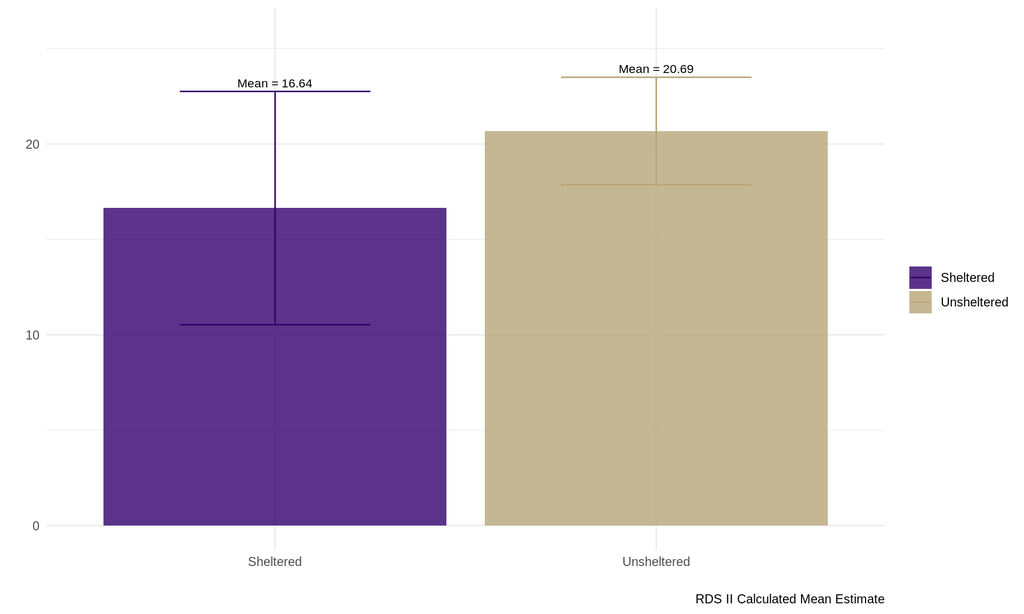

# Health

## *Health Status*

*Imputed based on ‘D1. In general, would you say your health is’ [UWRDS-PSD] and ‘16. How would you rate your health status?’ [UWRDS]*

Sheltered

Ego Health Status

Sample N

Sample Proportion

RDS II Estimate

RDS II 95% CI

Excellent

12

11.43%

12.29%

[1.31%, 23.26%]

Fair

45

42.86%

47.11%

[28.21%, 66.00%]

Good

42

40.00%

34.77%

[17.85%, 51.68%]

Poor

6

5.71%

5.84%

[-3.64%, 15.32%]

Total

105

Unsheltered

Ego Health Status

Sample N

Sample Proportion

RDS II Estimate

RDS II 95% CI

Excellent

68

9.67%

11.46%

[7.45%, 15.47%]

Fair

270

38.41%

37.09%

[30.08%, 44.10%]

Good

268

38.12%

36.30%

[29.70%, 42.91%]

Poor

97

13.80%

15.15%

[9.25%, 21.05%]

Total

703

*The difference between individual sheltered and unsheltered is not significant, $\chi^2 = 8.85$, (p = 0.15). These results were calculated based on the mean of 1000 bootstrapped tests. This value was calculated with replacement.*

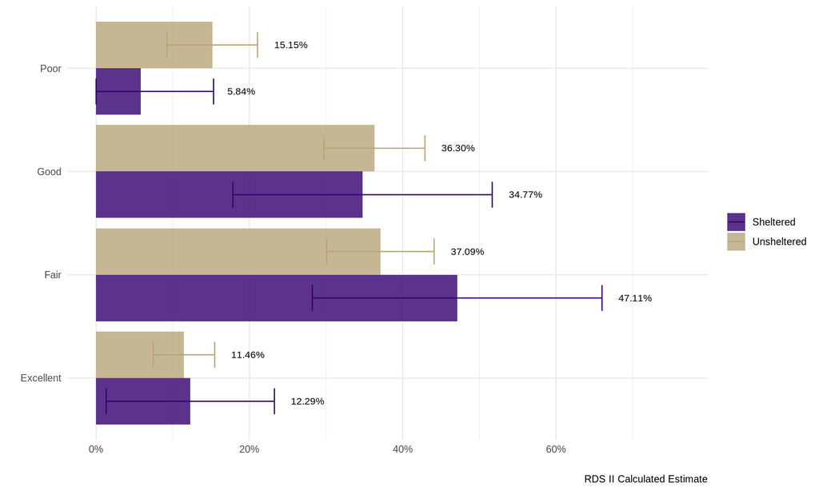

## *Disability*

*‘21. Do you identify as having a disability?’ This variable is not included for UWRDS-PSD survey observations.*

Sheltered

Have a Disability

Sample N

Sample Proportion

RDS II Estimate

RDS II 95% CI

Choose not to answer

0

NA

NA

NA

Do not know

1

1.08%

2.55%

[-2.68%, 7.78%]

No

39

41.94%

45.39%

[25.78%, 64.99%]

Yes

53

56.99%

52.06%

[32.49%, 71.64%]

Total

93

Unsheltered

Have a Disability

Sample N

Sample Proportion

RDS II Estimate

RDS II 95% CI

Choose not to answer

4

0.69%

1.28%

[-1.28%, 3.83%]

Do not know

19

3.26%

3.94%

[0.86%, 7.02%]

No

263

45.11%

47.78%

[39.94%, 55.61%]

Yes

297

50.94%

47.00%

[39.30%, 54.71%]

Total

583

*The difference between individual sheltered and unsheltered is not significant, $\chi^2 = 2.31$, (p = 0.872). These results were calculated based on the mean of 1000 bootstrapped tests. This value was calculated with replacement.*

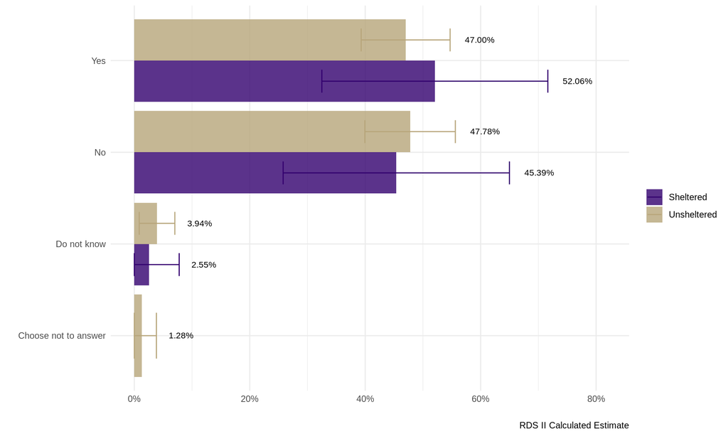

## *Mental Illness*

*‘20. Do you identify as having a serious mental illness?’ This variable is not included for UWRDS-PSD survey observations.*

Sheltered

Have a Mental Illness

Sample N

Sample Proportion

RDS II Estimate

RDS II 95% CI

Choose not to answer

0

NA

NA

NA

Do not know

3

3.23%

5.74%

[-5.97%, 17.4%]

No

56

60.22%

67.93%

[51.00%, 84.9%]

Yes

34

36.56%

26.33%

[11.65%, 41.0%]

Total

93

Unsheltered

Have a Mental Illness

Sample N

Sample Proportion

RDS II Estimate

RDS II 95% CI

Choose not to answer

9

1.54%

2.27%

[-0.37%, 4.9%]

Do not know

16

2.74%

3.09%

[-0.26%, 6.4%]

No

355

60.79%

62.89%

[55.37%, 70.4%]

Yes

204

34.93%

31.75%

[24.66%, 38.8%]

Total

584

*The difference between individual sheltered and unsheltered is not significant, $\chi^2 = 5.18$, (p = 0.627). These results were calculated based on the mean of 1000 bootstrapped tests. This value was calculated with replacement.*

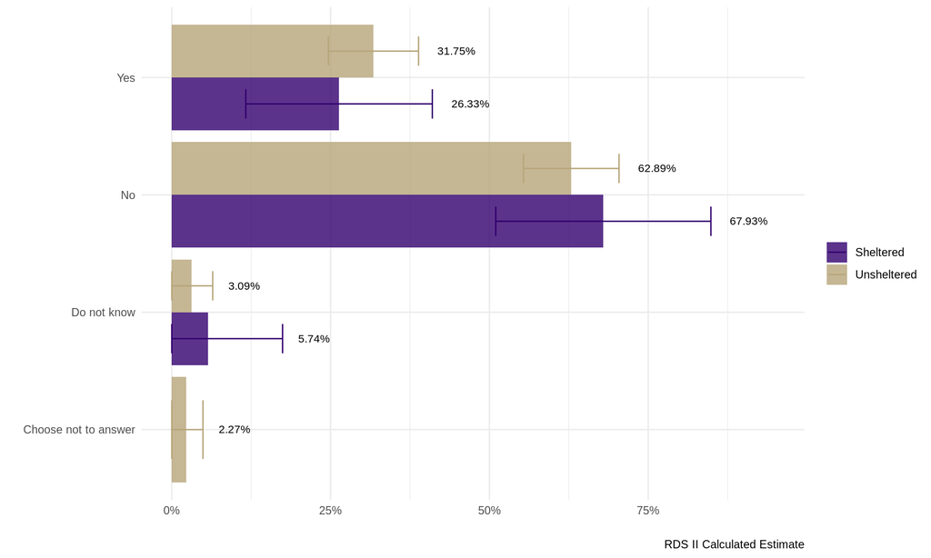

## *Substance Use*

*‘22. Do you identify as having a substance use disorder?’ This variable is not included for UWRDS-PSD survey observations.*

Sheltered

Have a Substance Use Disorder

Sample N

Sample Proportion

RDS II Estimate

RDS II 95% CI

Choose not to answer

0

NA

NA

NA

Do not know

1

1.08%

2.55%

[-2.7%, 7.8%]

No

56

60.22%

65.16%

[47.6%, 82.7%]

Yes

36

38.71%

32.29%

[15.2%, 49.4%]

Total

93

Unsheltered

Have a Substance Use Disorder

Sample N

Sample Proportion

RDS II Estimate

RDS II 95% CI

Choose not to answer

7

1.20%

1.68%

[-1.5%, 4.9%]

Do not know

5

0.86%

1.07%

[-0.3%, 2.5%]

No

280

48.03%

52.10%

[44.3%, 59.9%]

Yes

291

49.91%

45.15%

[37.4%, 52.9%]

Total

583

*The difference between individual sheltered and unsheltered is not significant, $\chi^2 = 9.15$, (p = 0.34). These results were calculated based on the mean of 1000 bootstrapped tests. This value was calculated with replacement.*

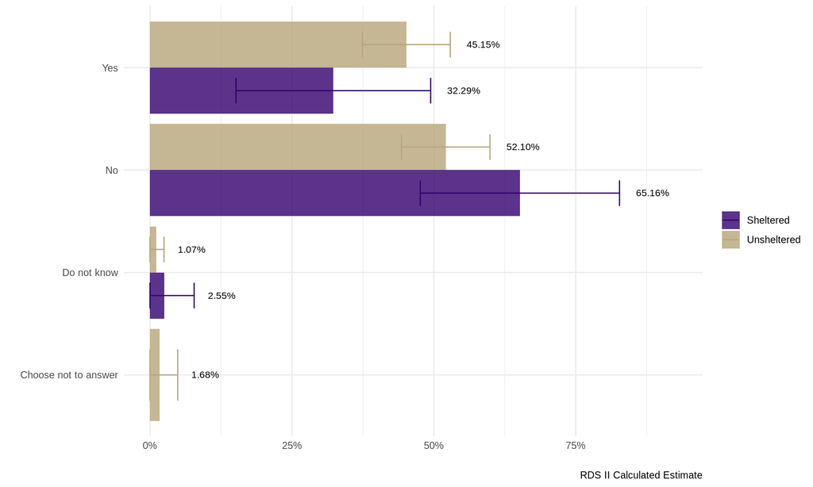

# Eviction

## *Ever Evicted*

*Imputed based on ‘15. Have you ever been evicted from a rental property?’ [UWRDS] and ‘Now think about the last place you lived, before you moved to your current residence. Were you forcibly evicted from that last place you lived?’ [UWRDS-PSD]*

Sheltered

Ever Evicted

Sample N

Sample Proportion

RDS II Estimate

RDS II 95% CI

No

76

74.51%

74.51%

[57.6%, 91.5%]

Yes

26

25.49%

25.49%

[8.5%, 42.4%]

Total

102

Unsheltered

Ever Evicted

Sample N

Sample Proportion

RDS II Estimate

RDS II 95% CI

No

485

75.43%

75.30%

[68.7%, 81.9%]

Yes

158

24.57%

24.70%

[18.1%, 31.3%]

Total

643

*The difference between individual sheltered and unsheltered is not significant, $\chi^2 = 0.03$, (p = 0.953). These results were calculated based on the mean of 1000 bootstrapped tests. This value was calculated with replacement.*

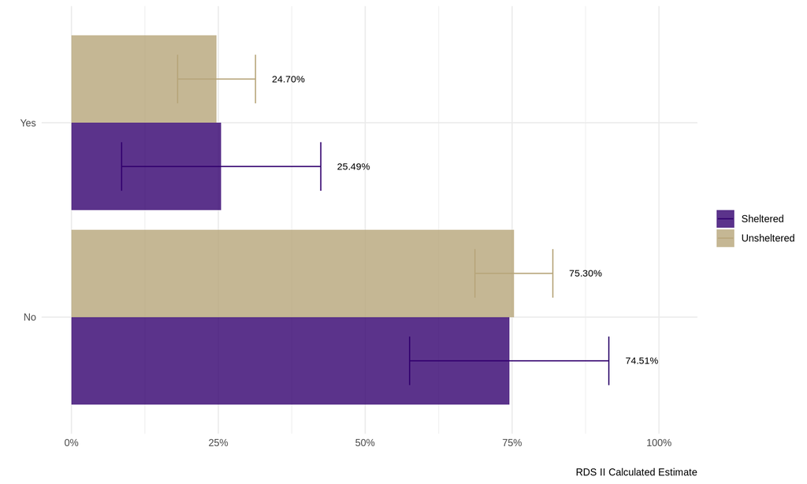

## *Age at Eviction*

*Imputed based on ‘15.1 How old were you? (please enter a number, for example: 30) [if yes to ’15. Have you ever been evicted from a rental property?’]’ This variable is not included for UWRDS-PSD survey observations.*

| Sleep Status | Sample N | Sample Median | Sample Mean | Sample SE | RDS II Estimate | RDS II 95% CI |
| --- | --- | --- | --- | --- | --- | --- |
| Unsheltered | 136 | 28 | 30.15 | 1.07 | 31.31 | [26.68, 35.94] |
| Sheltered | 23 | 31 | 34.78 | 3.23 | 33.48 | [28.82, 38.15] |

*The difference between individual sheltered and unsheltered is not significant, t(75.99) = 0.65, (p= 0.519).*

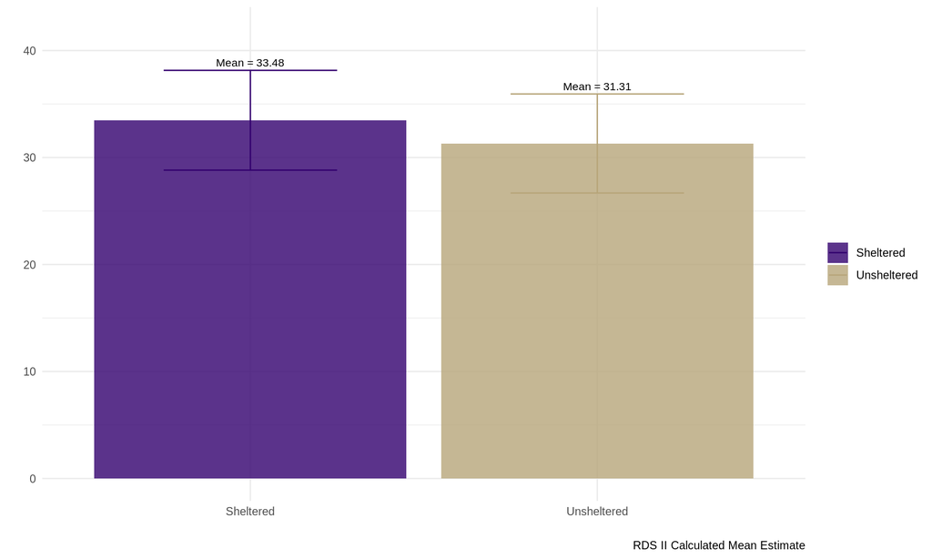

## *If Evicted, Ever Formally Evicted*

*‘15.2 Were you formally evicted by court order?’ This variable is not included for UWRDS-PSD survey observations.*

Sheltered

Ever Formally Evicted

Sample N

Sample Proportion

RDS II Estimate

RDS II 95% CI

No

6

27%

22%

[-1.6%, 46.4%]

Yes

16

73%

78%

[53.6%, 101.6%]

Total

22

Unsheltered

Ever Formally Evicted

Sample N

Sample Proportion

RDS II Estimate

RDS II 95% CI

No

79

58%

60%

[44.5%, 76.4%]

Yes

57

42%

40%

[23.6%, 55.5%]

Total

136

*The difference between individual sheltered and unsheltered is significant at the .05 level, $\chi^2 = 11.91$, (p = 0.021). These results were calculated based on the mean of 1000 bootstrapped tests. This value was calculated with replacement.*

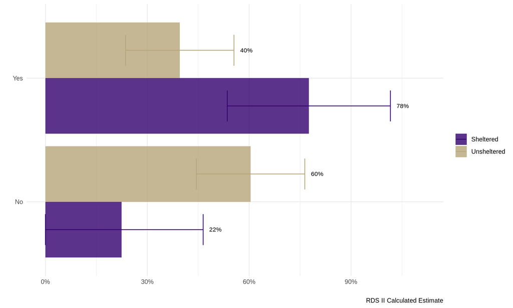

# Sleep Status

## *Location Slept Previous Night*

### *Where did you sleep last night?*

*Respondent’s sleep location based on ‘A. Regular residence’ in [UWRDS-PSD] and ‘7. Where did you sleep last night?’ [UWRDS]*

Sheltered

Sleep Location

Sample N

Sample Proportion

RDS II Estimate

RDS II 95% CI

Car or RV

0

NA

NA

NA

Mobile home or trailer

0

NA

NA

NA

No residence, I sleep outdoors

0

NA

NA

NA

Something else

7

6.31%

6.4%

[-7.51%, 20.3%]

Tent or homemade structure

0

NA

NA

NA

“Tiny home”

4

3.60%

2.6%

[0.32%, 4.9%]

Homeless shelter or hotel

100

90.09%

91.0%

[77.18%, 104.8%]

Total

111

Unsheltered

Sleep Location

Sample N

Sample Proportion

RDS II Estimate

RDS II 95% CI

Car or RV

159

21.26%

19.3%

[14.09%, 24.4%]

Mobile home or trailer

2

0.27%

0.4%

[-0.18%, 0.9%]

No residence, I sleep outdoors

252

33.69%

38.3%

[31.13%, 45.4%]

Something else

80

10.70%

10.8%

[6.78%, 14.8%]

Tent or homemade structure

255

34.09%

31.3%

[25.33%, 37.3%]

“Tiny home”

0

NA

NA

NA

Homeless shelter or hotel

0

NA

NA

NA

Total

748

*The difference between individual sheltered and unsheltered is significant at the .05 level, $\chi^2 = 795.47$, (p = 0). These results were calculated based on the mean of 1000 bootstrapped tests. This value was calculated with replacement.*

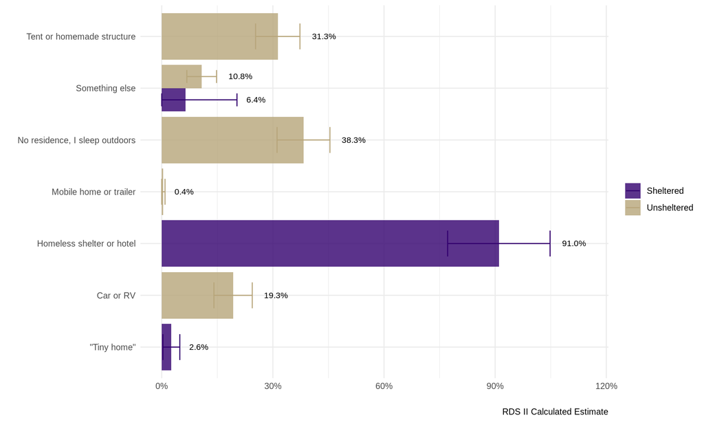

### *Re-coded: Where did you sleep last night?*

*7. Where did you sleep last night? - Imputed*

Sheltered

Sleep Location

Sample N

Sample Proportion

RDS II Estimate

RDS II 95% CI

Commercial property (e.g. shops)

0

NA

NA

NA

Did not sleep

0

NA

NA

NA

In a car, truck, or van (smaller vehicle)

0

NA

NA

NA

In a park (uncovered, like on a bench)

0

NA

NA

NA

In a public facility or transit (bus/train station, transit center, hospital waiting room)

0

NA

NA

NA

In an RV, trailer, or bus (larger vehicle)

0

NA

NA

NA

In an abandoned building/backyard or storage structure

0

NA

NA

NA

Maritime accommodation (e.g. boats, cargo)

0

NA

NA

NA

Outside in a tent (or tent-like structure)

0

NA

NA

NA

Outside, not in a tent

0

NA

NA

NA

Workplace

0

NA

NA

NA

In a hotel or motel

20

21.510%

22.58%

[8.81%, 36.36%]

In an overnight shelter (e.g. mission, church, resource shelter, etc.)

63

67.740%

68.02%

[49.69%, 86.35%]

Subsidized housing, housing vouchers

4

4.300%

4.51%

[-5.56%, 14.57%]

Tiny homes (not self-constructed)

3

3.230%

1.81%

[0.32%, 3.30%]

Transitional, supportive, or halfway housing

3

3.230%

3.08%

[-9.15%, 15.32%]

Total

93

Unsheltered

Sleep Location

Sample N

Sample Proportion

RDS II Estimate

RDS II 95% CI

Commercial property (e.g. shops)

1

0.170%

0.24%

[-0.52%, 1.01%]

Did not sleep

18

3.070%

2.41%

[1.08%, 3.74%]

In a car, truck, or van (smaller vehicle)

81

13.820%

13.46%

[7.83%, 19.09%]

In a park (uncovered, like on a bench)

19

3.240%

3.46%

[2.03%, 4.88%]

In a public facility or transit (bus/train station, transit center, hospital waiting room)

41

7.000%

8.49%

[4.18%, 12.79%]

In an RV, trailer, or bus (larger vehicle)

46

7.850%

6.25%

[3.55%, 8.94%]

In an abandoned building/backyard or storage structure

16

2.730%

2.63%

[0.03%, 5.23%]

Maritime accommodation (e.g. boats, cargo)

3

0.510%

0.68%

[0.09%, 1.27%]

Outside in a tent (or tent-like structure)

194

33.110%

29.92%

[23.16%, 36.67%]

Outside, not in a tent

166

28.330%

32.32%

[24.12%, 40.51%]

Workplace

1

0.170%

0.16%

[0.12%, 0.20%]

In a hotel or motel

0

NA

NA

NA

In an overnight shelter (e.g. mission, church, resource shelter, etc.)

0

NA

NA

NA

Subsidized housing, housing vouchers

0

NA

NA

NA

Tiny homes (not self-constructed)

0

NA

NA

NA

Transitional, supportive, or halfway housing

0

NA

NA

NA

Total

586

*The difference between individual sheltered and unsheltered is significant at the .05 level, $\chi^2 = 643.36$, (p = 0). These results were calculated based on the mean of 1000 bootstrapped tests. This value was calculated with replacement.*

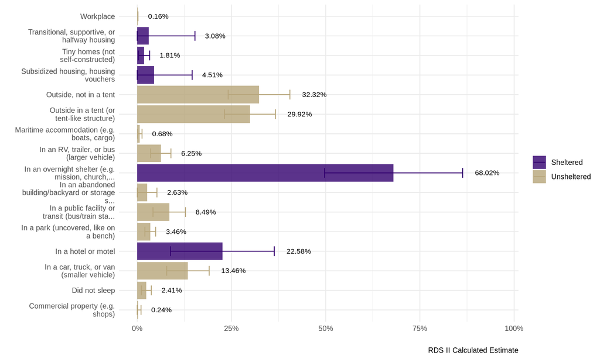

# Experience of Homelessness

## *First Year Experiencing Homelessness*

*‘10. What year was your first experience of homelessness?’ This variable is not included for UWRDS-PSD survey observations.*

| Sleep Status | Sample N | Sample Median | Sample Mean | Sample SE | RDS II Estimate | RDS II 95% CI |
| --- | --- | --- | --- | --- | --- | --- |
| Unsheltered | 583 | 2013 | 2009.49 | 0.50 | 2009.48 | [2007.02, 2011.93] |
| Sheltered | 91 | 2016 | 2011.80 | 1.35 | 2011.36 | [2006.36, 2016.37] |

*The difference between individual sheltered and unsheltered is not significant, t(356.8) = 0.66, (p= 0.508).*

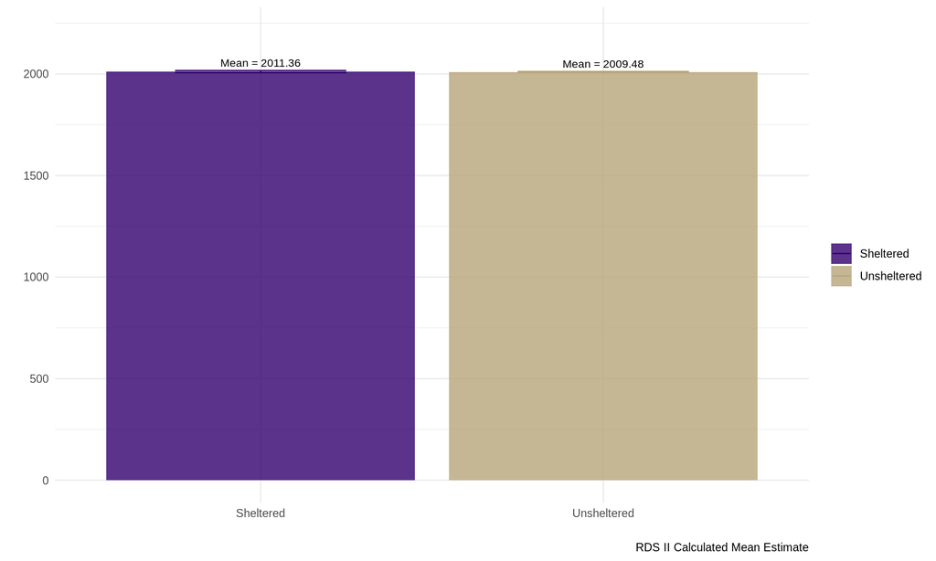

## *Time Experiencing Homelessness*

*Imputed based on ‘About how long have you been homeless’ [UWRDS-PSD] and ‘17. How long have you been homeless this time?’ [UWRDS-PSD]*

Sheltered

Duration Homeless

Sample N

Sample Proportion

RDS II Estimate

RDS II 95% CI

Above one year

64

61.54%

57.16%

[38.35%, 75.97%]

Choose not to answer

3

2.88%

3.34%

[-6.07%, 12.75%]

Do not know

0

NA

NA

NA

Less than a month

3

2.88%

4.14%

[-7.80%, 16.08%]

More than a month but Less than a year

34

32.69%

35.36%

[18.03%, 52.69%]

Total

104

Unsheltered

Duration Homeless

Sample N

Sample Proportion

RDS II Estimate

RDS II 95% CI

Above one year

540

77.25%

75.37%

[69.00%, 81.73%]

Choose not to answer

2

0.29%

0.23%

[-0.37%, 0.83%]

Do not know

6

0.86%

0.76%

[-0.03%, 1.56%]

Less than a month

29

4.15%

5.26%

[1.64%, 8.88%]

More than a month but Less than a year

122

17.45%

18.38%

[12.69%, 24.07%]

Total

699

*The difference between individual sheltered and unsheltered is significant at the .05 level, $\chi^2 = 33.12$, (p = 0.021). These results were calculated based on the mean of 1000 bootstrapped tests. This value was calculated with replacement.*

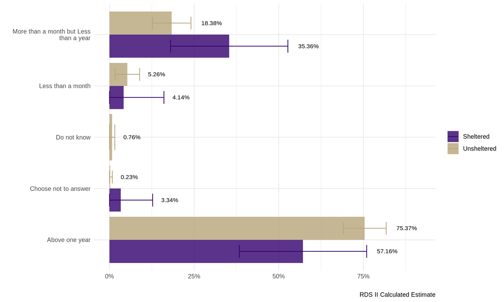

## *Days Homeless in Past Three Years*

*‘If you added up all the times you have been homeless in the last 3 years, about how long have you been homeless? - Imputed Total Days’ This variable is not included for UWRDS-PSD survey observations.*

| Sleep Status | Sample N | Sample Median | Sample Mean | Sample SE | RDS II Estimate | RDS II 95% CI |
| --- | --- | --- | --- | --- | --- | --- |
| Unsheltered | 586 | 1095.0 | 862.15 | 14.23 | 843.09 | [779.91, 906.28] |
| Sheltered | 93 | 730.5 | 671.18 | 44.46 | 660.19 | [495.66, 824.71] |

*The difference between individual sheltered and unsheltered is significant at the .05 level, t(366.75) = -2.03, (p= 0.043).*

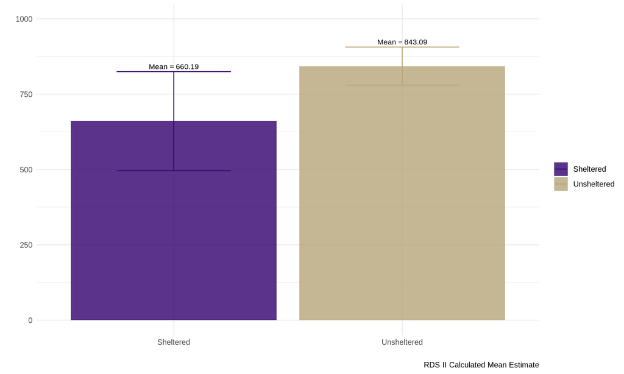

## *Number of Times Homeless in Past Three Years*

*‘18. Including this time, how many different times have you been homeless in the past 3 years, that is since April 2020?’ This variable is not included for UWRDS-PSD survey observations.*

Sheltered

Times Homeless

Sample N

Sample Proportion

RDS II Estimate

RDS II 95% CI

1 time

67

72.04%

65.80%

[42.76%, 88.84%]

2 times

11

11.83%

14.94%

[-7.34%, 37.22%]

3 times

1

1.08%

2.55%

[-0.78%, 5.88%]

4 or more times

9

9.68%

9.88%

[-2.88%, 22.65%]

Choose not to answer

2

2.15%

1.21%

[0.23%, 2.20%]

Do not know

3

3.23%

5.61%

[-6.31%, 17.53%]

Total

93

Unsheltered

Times Homeless

Sample N

Sample Proportion

RDS II Estimate

RDS II 95% CI

1 time

396

67.69%

67.68%

[60.61%, 74.76%]

2 times

80

13.68%

14.19%

[8.27%, 20.11%]

3 times

38

6.50%

7.26%

[4.05%, 10.47%]

4 or more times

58

9.91%

8.41%

[4.78%, 12.03%]

Choose not to answer

3

0.51%

0.97%

[0.07%, 1.86%]

Do not know

10

1.71%

1.50%

[0.32%, 2.67%]

Total

585

*The difference between individual sheltered and unsheltered is not significant, $\chi^2 = 10.01$, (p = 0.549). These results were calculated based on the mean of 1000 bootstrapped tests. This value was calculated with replacement.*

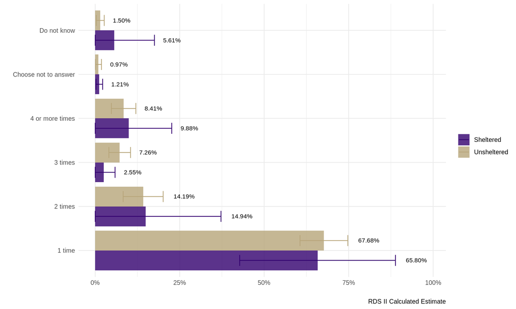

## *Experiencing Chronic Homelessness*

*Binary imputed variable for HUD’s chronic homelessness designation*

Sheltered

Experiencing Chronic Homelessness

Sample N

Sample Proportion

RDS II Estimate

RDS II 95% CI

No

48

51.6%

62.4%

[44.0%, 80.8%]

Yes

45

48.4%

37.6%

[19.2%, 56.0%]

Total

93

Unsheltered

Experiencing Chronic Homelessness

Sample N

Sample Proportion

RDS II Estimate

RDS II 95% CI

No

203

34.6%

39.6%

[31.6%, 47.7%]

Yes

383

65.4%

60.4%

[52.3%, 68.4%]

Total

586

*The difference between individual sheltered and unsheltered is significant at the .05 level, $\chi^2 = 18.17$, (p = 0.001). These results were calculated based on the mean of 1000 bootstrapped tests. This value was calculated with replacement.*

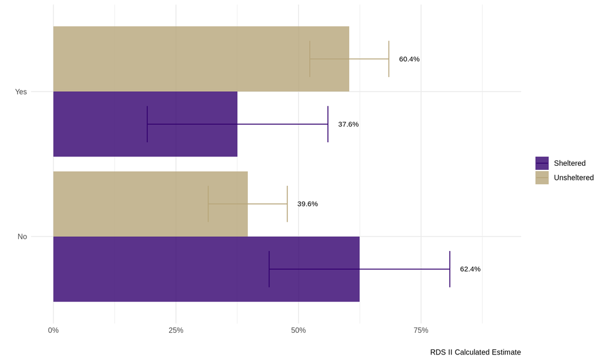

# Connections

## *Number of Estimated Homeless People Known*

*Outside of your family living with you, how many people do you personally know who are unhoused or experiencing homelessness? - Imputed*

| Sleep Status | Sample N | Sample Median | Sample Mean | Sample SE | RDS II Estimate | RDS II 95% CI |
| --- | --- | --- | --- | --- | --- | --- |
| Unsheltered | 727 | 12 | 78.52 | 28.68 | 84.77 | [-50.14, 219.69] |
| Sheltered | 107 | 5 | 33.23 | 11.37 | 20.65 | [7.59, 33.71] |

*The difference between individual sheltered and unsheltered is not significant, t(0.26) = -0.93, (p= 0.72).*

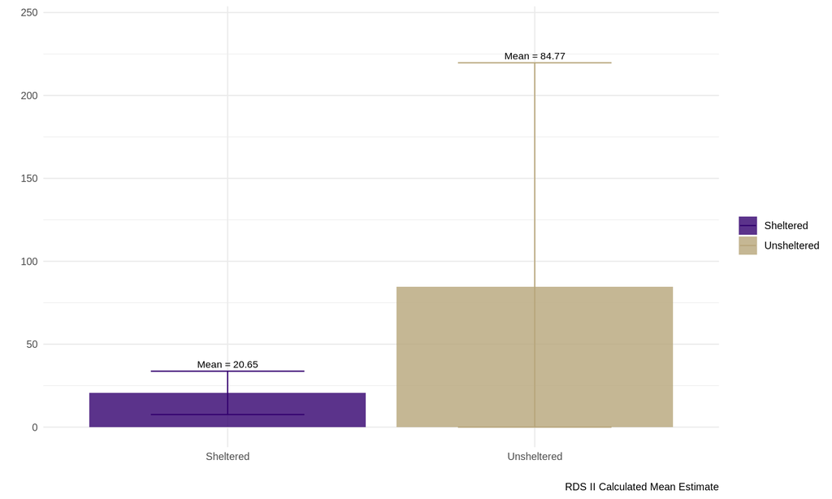

## *Number of Named Homeless People Known*

*Number of named non-household contacts*

| Sleep Status | Sample N | Sample Median | Sample Mean | Sample SE | RDS II Estimate | RDS II 95% CI |
| --- | --- | --- | --- | --- | --- | --- |
| Unsheltered | 748 | 3 | 4.18 | 0.16 | 1.87 | [1.57, 2.18] |
| Sheltered | 111 | 3 | 4.13 | 0.44 | 1.77 | [1.06, 2.48] |

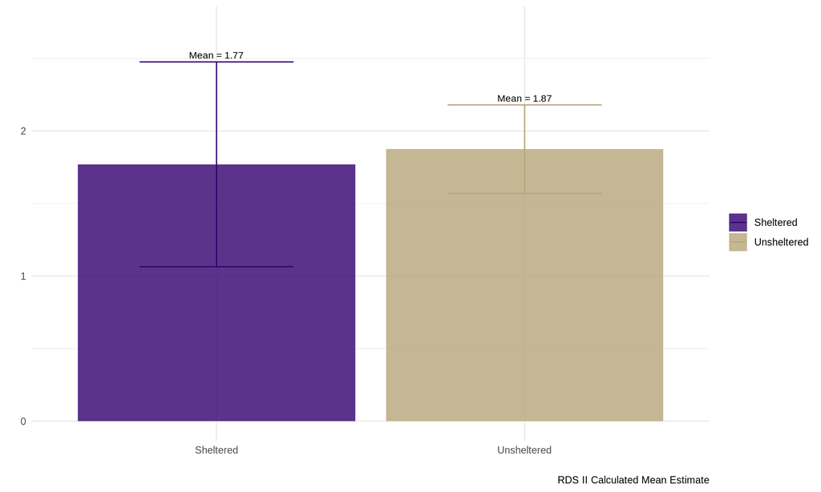

## *Number of Household Members*

*Imputed count of household members based on ‘27. Please list the initials of all the people in your household.’*

| Sleep Status | Sample N | Sample Median | Sample Mean | Sample SE | RDS II Estimate | RDS II 95% CI |
| --- | --- | --- | --- | --- | --- | --- |
| Unsheltered | 588 | 0 | 0.53 | 0.04 | 0.48 | [0.36, 0.61] |
| Sheltered | 93 | 0 | 0.96 | 0.20 | 0.57 | [0.28, 0.86] |

*The difference between individual sheltered and unsheltered is not significant, t(366.07) = 0.53, (p= 0.599).*

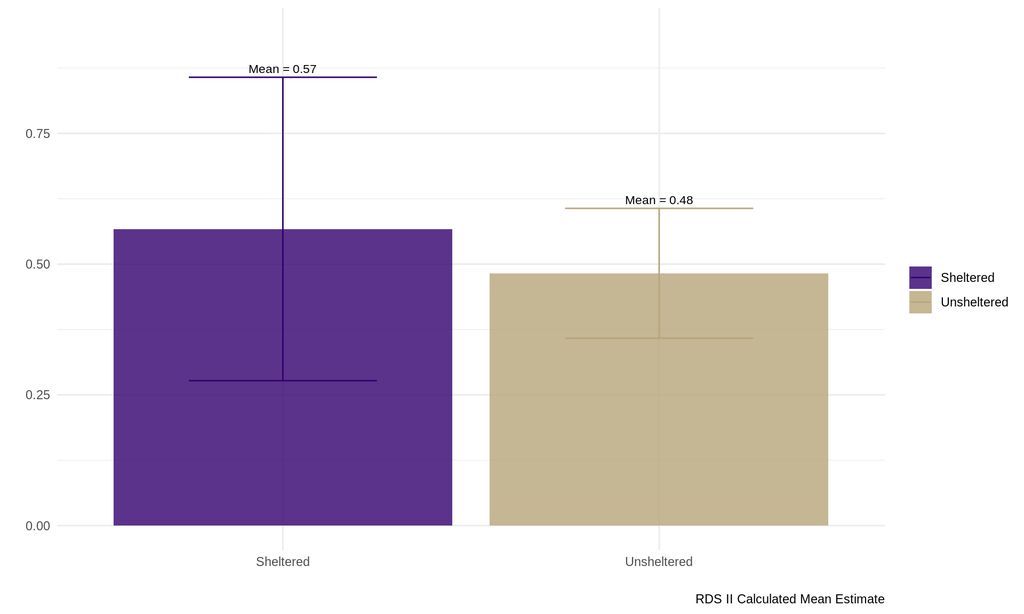

## *Number of Coupons Distributed*

*Total number of individuals the respondent referred who took the survey*

| Sleep Status | Sample N | Sample Median | Sample Mean | Sample SE | RDS II Estimate | RDS II 95% CI |
| --- | --- | --- | --- | --- | --- | --- |
| Unsheltered | 746 | 3 | 2.88 | 0.02 | 2.86 | [2.76, 2.96] |
| Sheltered | 111 | 3 | 2.91 | 0.04 | 2.89 | [2.58, 3.2] |

*The difference between individual sheltered and unsheltered is not significant, t(439.32) = 0.17, (p= 0.863).*

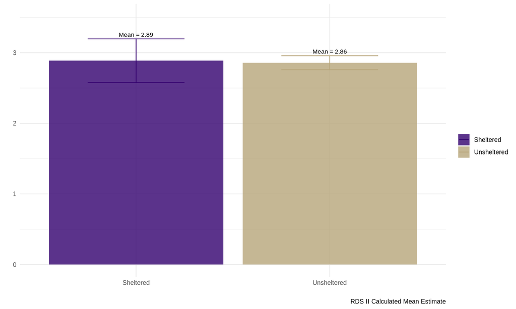

# Benefits

## *Veteran Affairs Benefits*

*‘13. Are you receiving any of the following benefits? (Select all that apply) - Selected Choice Veteran’s Administration (VA)’ This variable is not included for UWRDS-PSD survey observations.*

Sheltered

Receiving VA Benefits

Sample N

Sample Proportion

RDS II Estimate

RDS II 95% CI

No or Chose Not to Answer

85

91.4%

92.6%

[89.1%, 96.2%]

Yes

8

8.6%

7.4%

[3.8%, 10.9%]

Total

93

Unsheltered

Receiving VA Benefits

Sample N

Sample Proportion

RDS II Estimate

RDS II 95% CI

No or Chose Not to Answer

575

98.1%

98.7%

[98.0%, 99.4%]

Yes

11

1.9%

1.3%

[0.6%, 2.0%]

Total

586

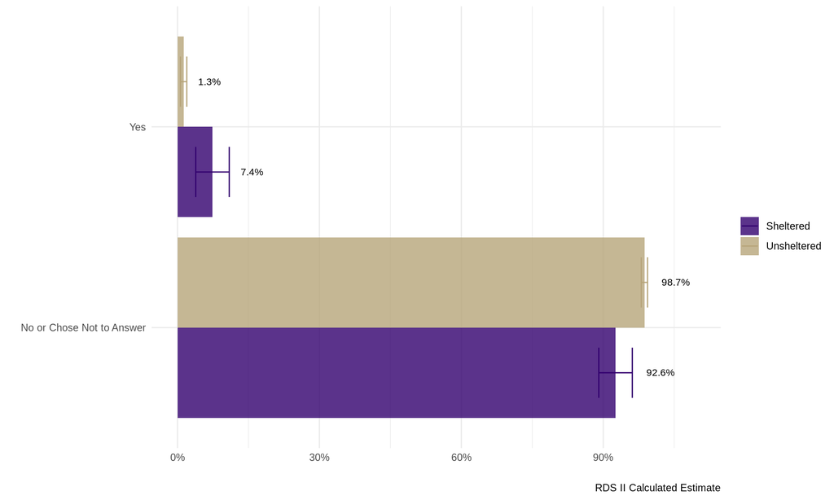

## *Disability Benefits*

*‘13. Are you receiving any of the following benefits? (Select all that apply) - Selected Choice WA Aged, Blind, or Disabled cash assistance’ This variable is not included for UWRDS-PSD survey observations.*

Sheltered

Receiving Disability Benefits

Sample N

Sample Proportion

RDS II Estimate

RDS II 95% CI

No or Chose Not to Answer

84

90.3%

95.4%

[91.4%, 99.4%]

Yes

9

9.7%

4.6%

[0.6%, 8.6%]

Total

93

Unsheltered

Receiving Disability Benefits

Sample N

Sample Proportion

RDS II Estimate

RDS II 95% CI

No or Chose Not to Answer

540

92.2%

91.8%

[87.8%, 95.8%]

Yes

46

7.8%

8.2%

[4.2%, 12.2%]

Total

586

*The difference between individual sheltered and unsheltered is not significant, $\chi^2 = 1.6$, (p = 0.446). These results were calculated based on the mean of 1000 bootstrapped tests. This value was calculated with replacement.*

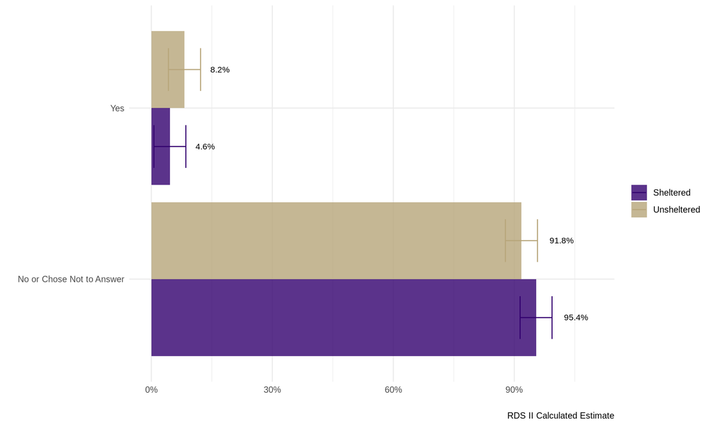